# Week 06 Quarto Homework

Author

Timothy Li

Published

October 6, 2026

# I’m creating a **plot** and **table** with the Chemistry Data set from Silbiger et al. 2020

### The first step is loading the libraries and reading in the data

```r
### Load in Libraries #####

library(tidyverse)
library(here)
library(kableExtra)

##### Read in Data #####

ChemData <- read_csv(here("Week_06", "Data", "chemicaldata_maunalua.csv"))
glimpse(ChemData)
```

```
Rows: 355
Columns: 15
$ Waypoint    <dbl> 1, 2, 3, 4, 5, 6, 7, 8, 9, 10, 11, 12, 13, 14, 15, 16, 17,…
$ Zone        <chr> "Transition", "Transition", "Transition", "Transition", "D…
$ Lat         <dbl> 21.27531, 21.27523, 21.27504, 21.27449, 21.27503, 21.27485…
$ Long        <dbl> -157.7618, -157.7627, -157.7633, -157.7640, -157.7617, -15…
$ Site        <chr> "W", "W", "W", "W", "W", "W", "W", "W", "W", "W", "W", "W"…
$ Season      <chr> "SPRING", "SPRING", "SPRING", "SPRING", "SPRING", "SPRING"…
$ Tide_time   <chr> "Low_Day", "Low_Day", "Low_Day", "Low_Day", "Low_Day", "Lo…
$ Temp_in     <dbl> 23.75506, 23.53256, 22.63450, 24.01982, 23.26102, 24.00517…
$ Salinity    <dbl> 27.74029, 30.61192, 28.37008, 32.82124, 29.12293, 34.02018…
$ Phosphate   <dbl> 0.54, 0.36, 0.50, 0.25, 0.50, 0.13, 0.28, 0.15, 0.23, 0.11…
$ Silicate    <dbl> 157.93, 92.59, 143.60, 42.32, 126.47, 15.04, 56.31, 23.10,…
$ NN          <dbl> 7.92, 3.37, 7.29, 0.79, 7.45, 0.46, 1.59, 0.34, 1.91, 0.25…
$ pH          <dbl> 7.909, 7.965, 8.023, 7.995, 8.005, 8.019, 8.003, 7.978, 7.…
$ TA          <dbl> 2161.482, 2145.828, 2272.391, 2219.583, 2151.826, 2216.758…
$ percent_sgd <dbl> 20.4043928, 11.9625323, 18.5529716, 5.4677003, 16.3397933,…
```

### The second step is cleaning up the data!

```r
##### Clean Data #####

ChemData_clean <- ChemData |>
  drop_na() |>            # Remove all NAs
  separate_wider_delim(cols  = Tide_time, # Separate the Tide_time column into 2 separate columns
                       delim = "_",
                       names = c("Tide", "Time"))

glimpse(ChemData_clean)
```

```
Rows: 318
Columns: 16
$ Waypoint    <dbl> 1, 2, 3, 4, 5, 6, 7, 8, 9, 10, 11, 12, 13, 14, 15, 16, 17,…
$ Zone        <chr> "Transition", "Transition", "Transition", "Transition", "D…
$ Lat         <dbl> 21.27531, 21.27523, 21.27504, 21.27449, 21.27503, 21.27485…
$ Long        <dbl> -157.7618, -157.7627, -157.7633, -157.7640, -157.7617, -15…
$ Site        <chr> "W", "W", "W", "W", "W", "W", "W", "W", "W", "W", "W", "W"…
$ Season      <chr> "SPRING", "SPRING", "SPRING", "SPRING", "SPRING", "SPRING"…
$ Tide        <chr> "Low", "Low", "Low", "Low", "Low", "Low", "Low", "Low", "L…
$ Time        <chr> "Day", "Day", "Day", "Day", "Day", "Day", "Day", "Day", "D…
$ Temp_in     <dbl> 23.75506, 23.53256, 22.63450, 24.01982, 23.26102, 24.00517…
$ Salinity    <dbl> 27.74029, 30.61192, 28.37008, 32.82124, 29.12293, 34.02018…
$ Phosphate   <dbl> 0.54, 0.36, 0.50, 0.25, 0.50, 0.13, 0.28, 0.15, 0.23, 0.11…
$ Silicate    <dbl> 157.93, 92.59, 143.60, 42.32, 126.47, 15.04, 56.31, 23.10,…
$ NN          <dbl> 7.92, 3.37, 7.29, 0.79, 7.45, 0.46, 1.59, 0.34, 1.91, 0.25…
$ pH          <dbl> 7.909, 7.965, 8.023, 7.995, 8.005, 8.019, 8.003, 7.978, 7.…
$ TA          <dbl> 2161.482, 2145.828, 2272.391, 2219.583, 2151.826, 2216.758…
$ percent_sgd <dbl> 20.4043928, 11.9625323, 18.5529716, 5.4677003, 16.3397933,…
```

### The third step is determining what we want to plot and plotting it! I’m choosing to focus on the relationship between *Phosphate* and *Silicate* concentrations in reference to what *Season* it is and what *Time* of day it is.

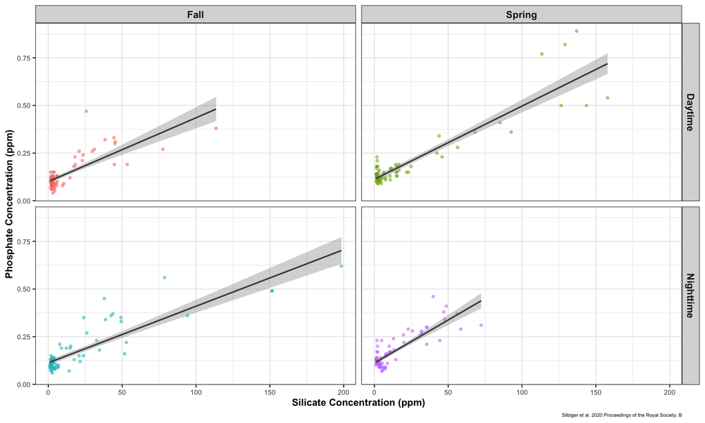

Figure 1: The Relationship Between Silicate Concentrations (ppm) and Phosphate Concentrations (ppm) During Different Seasons at Day and Night

```r
phosphate_silicate_plot <- ggplot(data = ChemData_clean,
                           mapping = aes(x = Silicate,
                                         y = Phosphate,
                                         color = interaction(Season, Time) # Interaction lets me have separate colors for each grided plot
                                         )) +
  geom_point(size = 1, alpha = 0.5) +
  facet_grid(Time ~ Season, # Grid separated by time and season (4 total plots)
             labeller = labeller(
               Season = c("FALL" = "Fall", "SPRING" = "Spring"), # Labeller changes the label names
               Time = c("Day" = "Daytime", "Night" = "Nighttime")
             ))  +
  scale_fill_viridis_d(option = "D") + # Color-blind friendly scale
  geom_smooth(method = "lm", linewidth = .75, color = "grey30") +
  labs(
       x = "Silicate Concentration (ppm)", y = "Phosphate Concentration (ppm)",
       caption = "Silbiger et al. 2020 Proceedings of the Royal Society: B"
  ) +
  theme_bw() +
  theme(
    plot.title = element_text(size = 13, hjust = .5, face = "bold"),
    axis.title.x = element_text(size = 10, face = "bold"),
    axis.title.y = element_text(size = 10, face = "bold"),
    plot.caption = element_text(size = 5),
    strip.text = element_text(size = 10, face = "bold"),
    axis.text.x = element_text(size = 7),
    axis.text.y = element_text(size = 7),
    legend.position = "none"
  )

phosphate_silicate_plot

##### Save Plot

ggsave(here("Week_06", "Outputs", "HW6_Phos_Sil_plot.png"), width = 10, height = 6)
```

### The final step is identifying some important takeaways from the plots. I also want to make a table of the important summary statistics to identify some of these takeaways much easier!

```r
##### Pivot into long format and Calculate Summary Statistics #####

ChemData_summary <- ChemData_clean |>
  pivot_longer(cols = Phosphate:Silicate, # Making the dataset longer
               names_to  = "Variables",
               values_to = "Values") |>
  group_by(Season, Time, Variables) |> # Summarizing for Variable and Zone
  summarise(Mean = mean(Values, na.rm = TRUE),
            Variability  = var(Values,  na.rm = TRUE),
            "Standard Deviation" = sd(Values, na.rm = TRUE)) |> # Finding mean, variability, and SD
  write_csv(here("Week_06", "Outputs", "HW06_summary.csv")) |>
  kbl() |> # Creates the table
  kable_classic() |> # Table theme
  kable_styling(full_width = FALSE) # Makes sure the table isn't too wide

ChemData_summary
```

| Season | Time | Variables | Mean | Variability | Standard Deviation |
| --- | --- | --- | --- | --- | --- |
| FALL | Day | Phosphate | 0.1372500 | 0.0064987 | 0.0806143 |
| FALL | Day | Silicate | 10.9743750 | 350.0697566 | 18.7101512 |
| FALL | Night | Phosphate | 0.1671250 | 0.0144081 | 0.1200337 |
| FALL | Night | Silicate | 18.2477500 | 1232.3786556 | 35.1052511 |
| SPRING | Day | Phosphate | 0.1933333 | 0.0250537 | 0.1582835 |
| SPRING | Day | Silicate | 20.9675641 | 1425.6725745 | 37.7580796 |
| SPRING | Night | Phosphate | 0.1670000 | 0.0075377 | 0.0868201 |
| SPRING | Night | Silicate | 12.2286250 | 265.3407867 | 16.2892844 |

Table 1: Summary Statistics for Phosphate (ppm) and Silicate (ppm) Concentrations

### Key Takeaways from the plots and summary statistics:

- All 4 plots have relatively strong and positive correlations
- Points are heavily concentrated at lower levels of Phosphate and Silicate
- Daytime in the Spring and Nightime in the Fall have Silicate concentrations above 150 ppm
  - These could potentially be outliers which could be tested using IQR
- Daytime in Spring has the highest mean Silicate and Phosphate concentrations (ppm)
- 198.43 is the max Silicate concentration (ppm)
- 0.89 is the max Phosphate concentration (ppm)